# Tick Location Ordinary Kriging Process

Roger

2025-02-18

## Mapping Tick Count Distributions in the Study Area

Understanding the spatial distribution of tick counts is crucial for identifying high-risk areas and guiding public health interventions. This section presents two maps visualizing the distribution of tick counts across the study area.

1. **Binary Classification Map:** This map categorizes sampled locations into two groups:
   - Locations with **zero tick counts** (blue).
   - Locations with **positive tick counts** (red).

   This classification helps differentiate between areas where ticks were not observed and areas where they were detected, which can provide insight into environmental or ecological factors influencing tick presence.
2. **Quartile Distribution Map:** For locations with **positive tick counts**, we further divide them into four quartiles:
   - **Q1 (Lowest counts)** – Green
   - **Q2 (Moderate counts)** – Yellow
   - **Q3 (High counts)** – Orange
   - **Q4 (Highest counts)** – Red

   This classification highlights areas with relatively higher tick populations, which may indicate breeding hotspots or regions with favorable tick habitats.

By overlaying these maps onto the city/town boundary shapefile, we can better understand the geographic trends of tick distributions. The following R chunk processes and visualizes this data.

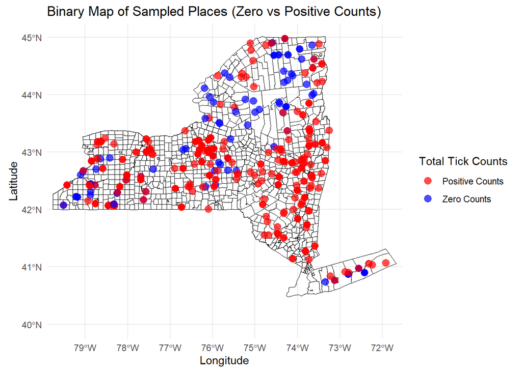

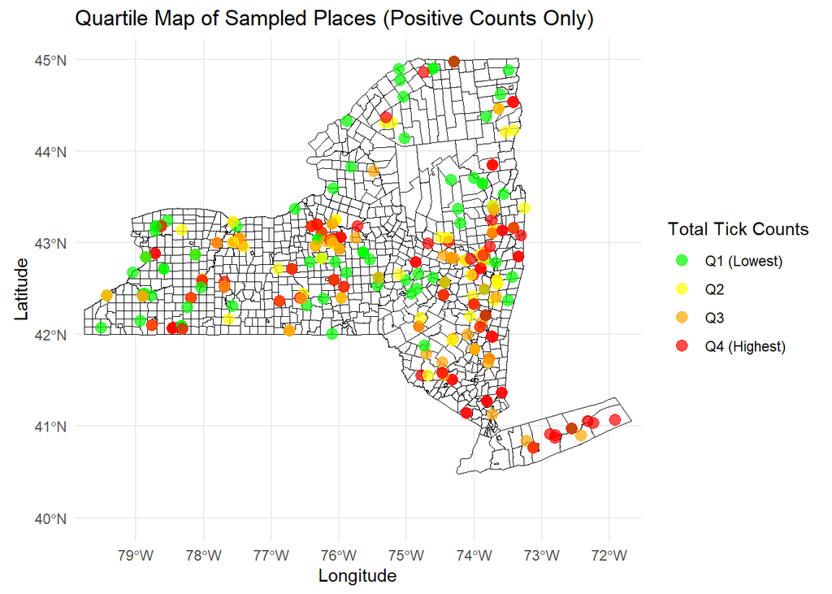

## Mapping Tick Count Distributions in the Study Area

Understanding the spatial distribution of tick counts is essential for identifying high-risk areas and guiding public health interventions. This section presents a **comprehensive map** visualizing the distribution of tick counts across the study area.

### **Categorization of Tick Counts**

This map categorizes sampled locations into the following groups:

1. **Zero Tick Counts (Blue):** Locations where no ticks were observed.
2. **Quartile-Based Classification of Positive Counts:**
   - **Q1 (Lowest Counts)** – Light Green
   - **Q2 (Moderate Counts)** – Yellow
   - **Q3 (High Counts)** – Orange
   - **Q4 (Highest Counts)** – Red

By classifying locations into these categories, we can: - Distinguish between areas where ticks were absent and where they were detected. - Identify **hotspots with high tick prevalence** that may indicate favorable environmental conditions for ticks. - Provide insights into **spatial trends of tick presence**, which can inform targeted control and mitigation strategies.

### **Overlaying Tick Data on City/Town Boundaries**

This map is overlaid onto **city and town boundaries** to contextualize tick distributions within **geographic and administrative regions**. This allows for a more precise interpretation of tick hotspots relative to human population centers and environmental factors.

The following R chunk processes the data and generates a **spatial visualization** of tick count distributions within the study area.

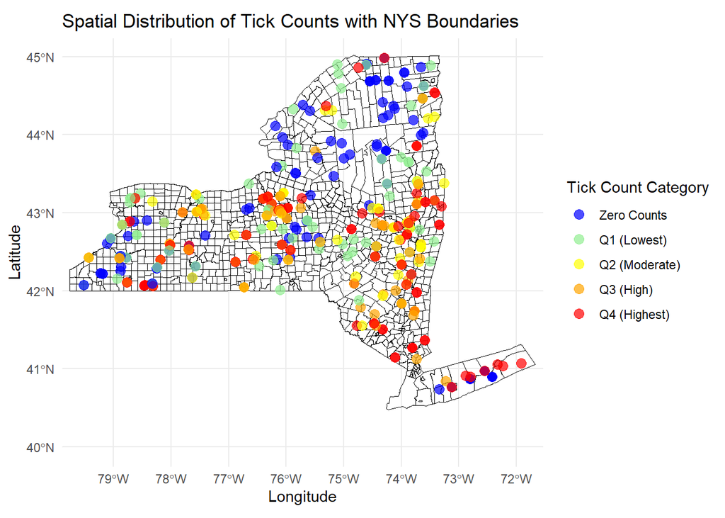

### Overview

This script performs spatial analysis on tick location (0 or 1) using **kriging interpolation**. It includes data preprocessing, variogram computation, and interpolation to predict tick distribution across a defined geographical grid.

### Steps in the Code

```r
# Compute the median tick count per unique location
tick <- df %>%
  group_by(binary_total, Location, Town, LAT, LONG, X_m, Y_m) %>%
  summarise(tick_median = median(binary_total, na.rm = TRUE), .groups = "drop")

# Convert coordinates to numeric
tick$LAT <- as.numeric(tick$LAT)
tick$LONG <- as.numeric(tick$LONG)

# Remove rows with missing coordinate values
tick <- tick %>% filter(!is.na(LAT) & !is.na(LONG))

# Remove duplicate coordinates, keeping only the first occurrence
tick <- tick %>%
  group_by(LONG, LAT) %>%
  filter(row_number() == 1) %>%
  ungroup()

# Create a data frame for geoR analysis
data <- data.frame(LONG = tick$LONG, LAT = tick$LAT, Counts = tick$tick_median)

# Convert to geoR object
geo_tick <- as.geodata(data, coord.col = c("LONG", "LAT"), data.col = 3)

# Ensure the 'data' variable contains LONG, LAT, and tick_median
coordinates(data) <- ~LONG + LAT

# Compute the empirical variogram
vgram <- variogram(Counts ~ 1, data = data)

# Fit a variogram model (using Spherical model)
vgram_model <- fit.variogram(vgram, model = vgm(psill = 0.12, "Exp", nugget = 0.1, range = 1))

# Create a prediction grid for kriging
grid <- expand.grid(
  LONG = seq(min(data$LONG), max(data$LONG), length.out = 100),
  LAT = seq(min(data$LAT), max(data$LAT), length.out = 100)
)
coordinates(grid) <- ~LONG + LAT
gridded(grid) <- TRUE

# Perform Ordinary Kriging
kriging_result <- krige(Counts ~ 1, locations = data, newdata = grid, model = vgram_model)
```

```
## [using ordinary kriging]
```

```r
krig_output <- as.data.frame(kriging_result)
names(krig_output) <- c("long","lat","OK_pred","OK_var")
boundaries <- st_transform(boundaries, crs = 4326)
OK_output_sf <- st_as_sf(krig_output,coords = c("long","lat"),crs=4326)
OK_mask_result <- st_intersection(OK_output_sf,boundaries)
```

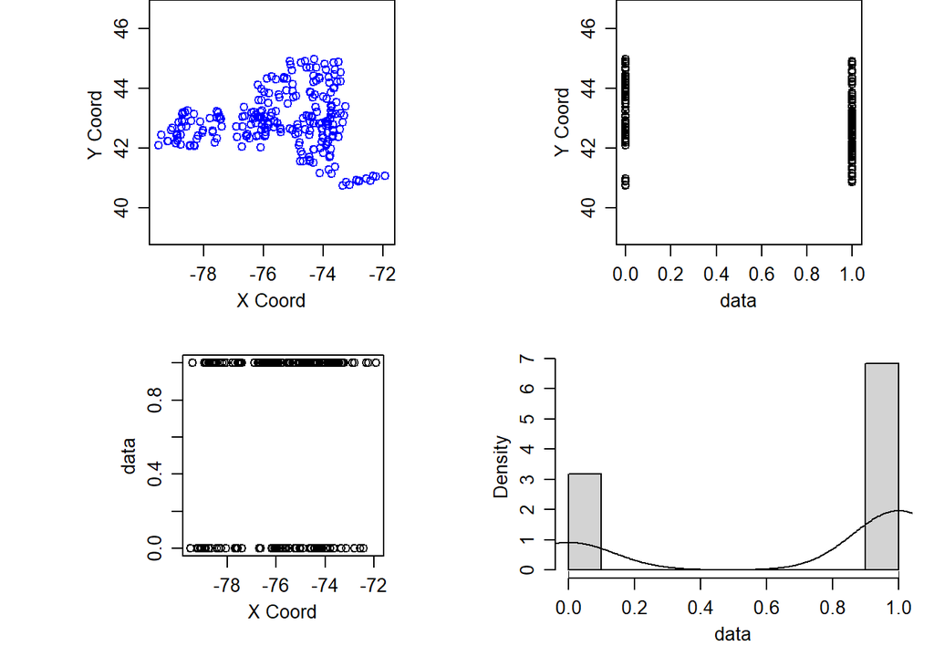

## Interpretation of the Tick Location Data Visualization

This figure provides an exploratory spatial analysis of tick presence data using kriging interpolation. The plot consists of four subplots:

1. **Top-left: Spatial Distribution of Observed Data**
   - This scatter plot shows the geographic distribution of tick presence data, with coordinates (longitude and latitude) on the x and y axes.
   - Each point represents an observation, and the density of points suggests regions with more frequent data collection.
2. **Top-right: Tick Presence by Latitude**
   - This plot illustrates the binary tick presence data (`data` = 0 or 1) along the latitude axis.
   - The data points are clustered at 0 and 1, indicating that the observations are classified strictly as presence (1) or absence (0) of ticks.
3. **Bottom-left: Tick Presence by Longitude**
   - Similar to the previous plot, this visualization maps the binary tick presence data along the longitude axis.
   - The clustering at 0 and 1 again confirms that the dataset consists of binary classifications rather than continuous values.
4. **Bottom-right: Distribution of Tick Presence Data**
   - This histogram and density plot show the distribution of the tick presence values.
   - The data is highly skewed, with most values at either 0 or 1, which is expected since the dataset is binary.
   - The density curve overlaid on the histogram provides an estimate of the probability density function, though it is primarily concentrated at the two extremes.

### Key points

This visualization confirms that the tick presence data is **binary** and spatially structured. The kriging prediction values in subsequent analyses will represent the **probability of tick presence** at different locations, ranging from 0 to 1. Areas with higher probabilities indicate a greater likelihood of encountering ticks.

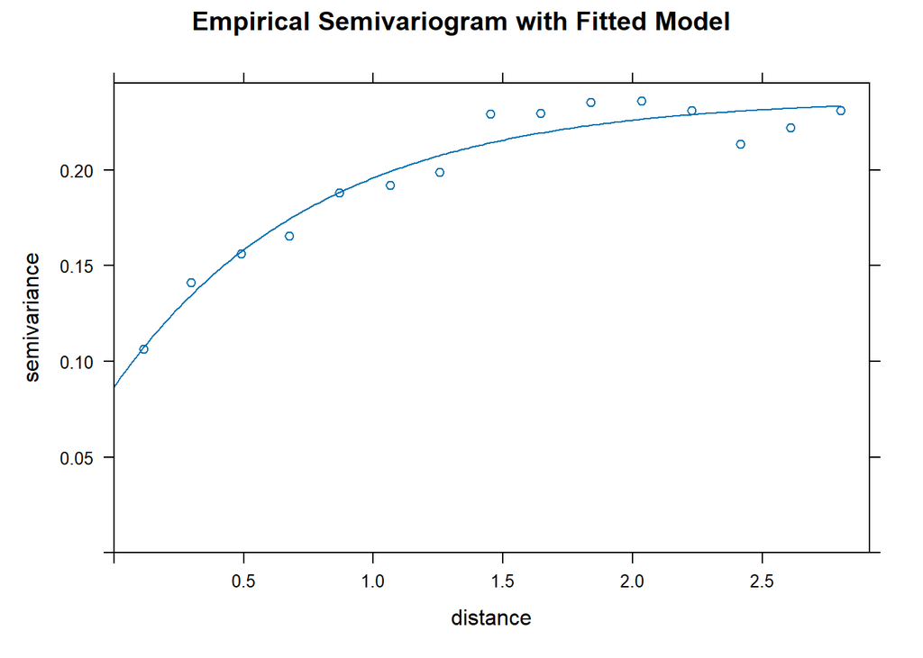

## Interpretation of the Empirical Semivariogram

### Interpretation

1. **Nugget Effect (near distance = 0)**
   - The y-intercept (~0.1) represents the **nugget effect**, which accounts for measurement error or spatial variability at very short distances.
2. **Range (~1.5 to 2.0)**
   - The curve increases and levels off around a **distance of 1.5 to 2.0**. This is the **range**, indicating that data points within this distance are spatially correlated.
   - Beyond this range, the semivariance remains constant, meaning there is no significant spatial correlation.
3. **Sill (~0.22)**
   - The **sill** is the plateau where the semivariance stabilizes, indicating the maximum variance due to spatial dependence.

### Key points

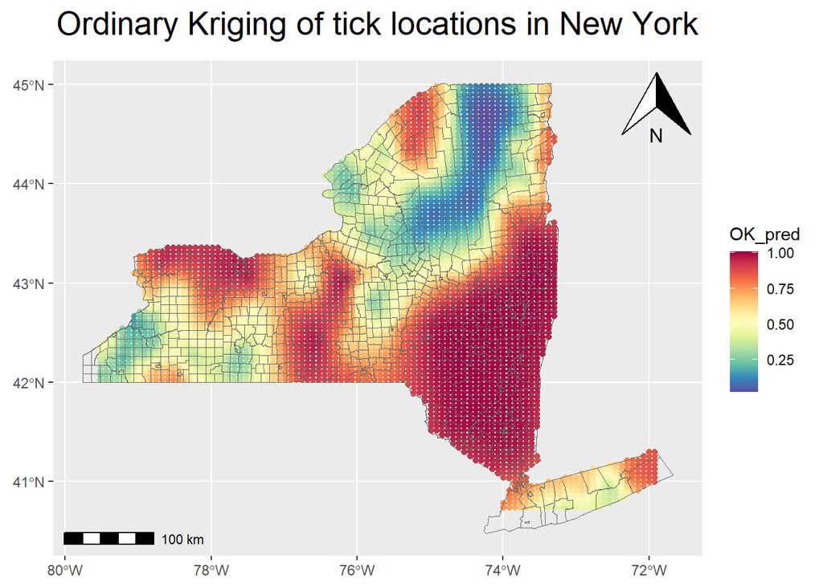

### Interpretation of Kriging Results

The final kriging prediction values range between **0 and 1**. Since the input data used for kriging is binary, the predicted values represent the **probability of tick presence** at a given location. Higher values indicate a higher likelihood of tick occurrence, while lower values suggest a lower probability. This probabilistic spatial interpolation allows for a better understanding of tick distribution patterns across the study area.